# `ggspectra` 0.1.7.9003 User Guide

## Plotting spectra

The most automatic way of plotting spectral data stored in one of the classes defined in package `photobiology` is to use the `plot()`methods. These go much further than the `plot()` method defined in base-R for numeric data, as these classes store metadata that allows the automatic construction of axis labels as quantities and units are well defined.

Here we use the same example `source_spct` object from package `photobiology` used earlier in the User Guide. In contrast to earlier examples, here we obtain with a very simple statement a very complete and properly annotated plot of the solar spectrum at ground level.

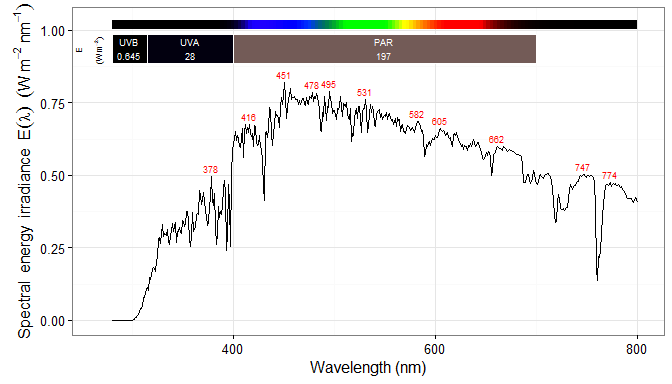

```r
plot(sun.spct)
```

Although the defaults provide a useful plot, the `plot()` method accepts arguments for several parameters that allow to tweak the looks and contents of the plots significantly, without having to do any explicit manipulation of the spectral data.

This first example, shows means instead of integrals in the labels. Note that the units and quantity labels for the waveband summaries have also changed automatically.

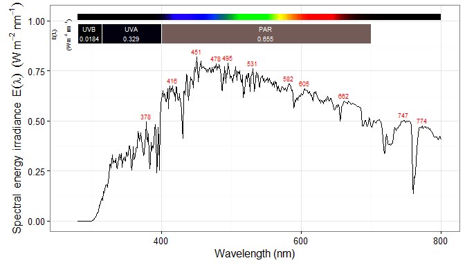

```r
plot(sun.spct, label.qty = "mean")
```

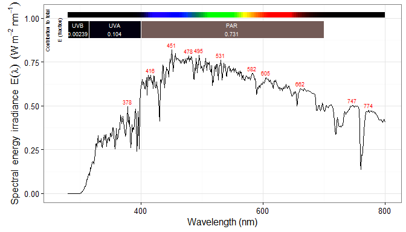

```r
plot(sun.spct, label.qty = "contribution")
```

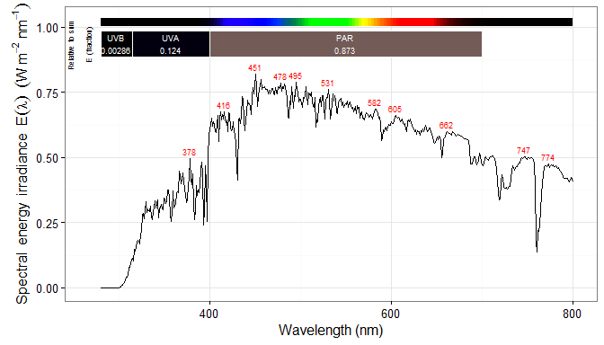

```r
plot(sun.spct, label.qty = "relative")
```

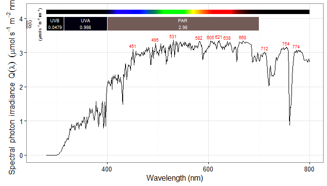

```r
plot(sun.spct, label.qty = "mean", unit.out = "photon")
```

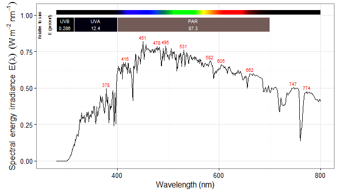

```r
plot(sun.spct, label.qty = "relative.pc")
```

We can change the basis of expression of spectral irradiance and irradiance from `"energy"` to `"photon"`. Be aware that by design, all values, summaries and spectral data will always use the same base of expression.

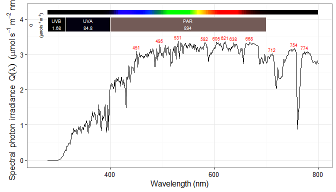

```r
plot(sun.spct, unit.out = "photon")
```

Which *annotations* are included can be also controlled through parameter `annotations`.

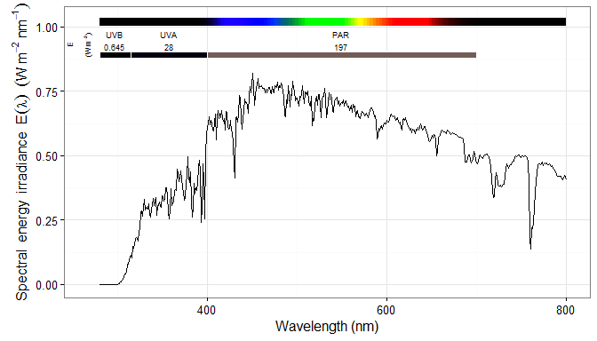

```r
plot(sun.spct,
     annotations = c("segments", "labels", "summaries", "color.guide"))
```

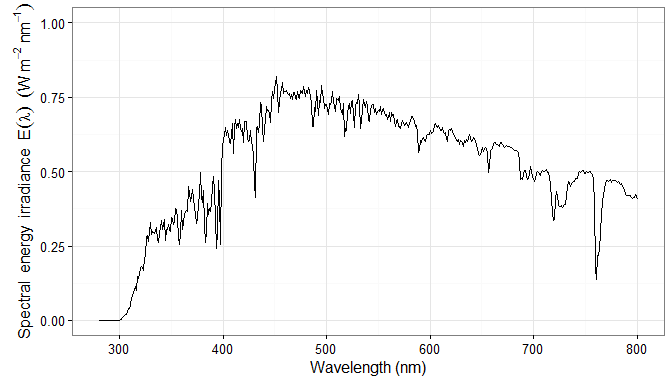

```r
plot(sun.spct,
     annotations = NULL)
```

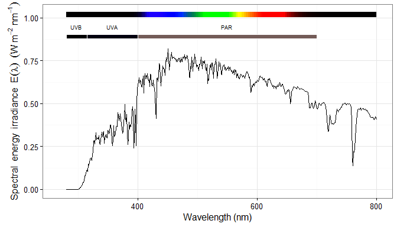

```r
plot(sun.spct, annotations = c("segments", "labels", "color.guide"))
```

The size of the font used for the annotations is controlled by argument `text.size`.

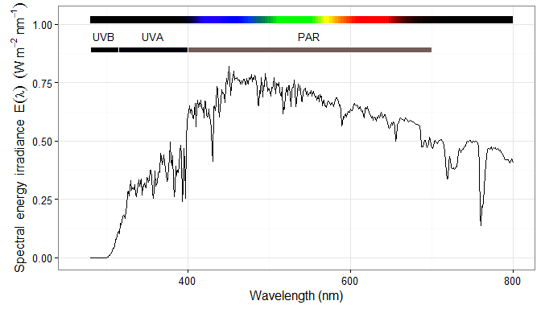

```r
plot(sun.spct,
     annotations = c("segments", "labels", "color.guide"),
     text.size = 3.5)
```

Arguments `range` and `w.band` play very different roles. The first one determines the `range` of wavelengths to include in the data plotted, which is slightly different to the effect of `ggplot2::xlim()` as `range` is used to *trim* (see `photobiology::trim_wl()`) the spectral data **before** passing it to `ggplot`. The second one, `w.band` is only used for the *annotations* and decorations. It should be however noted, that a `waveband` object is a valid argument for both `range` and `w.band`.

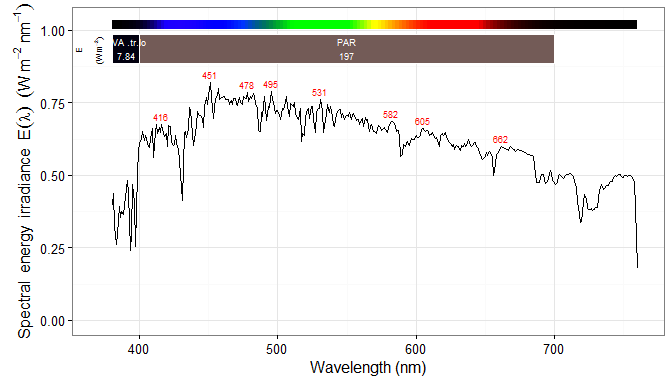

```r
plot(sun.spct, range = VIS())
```

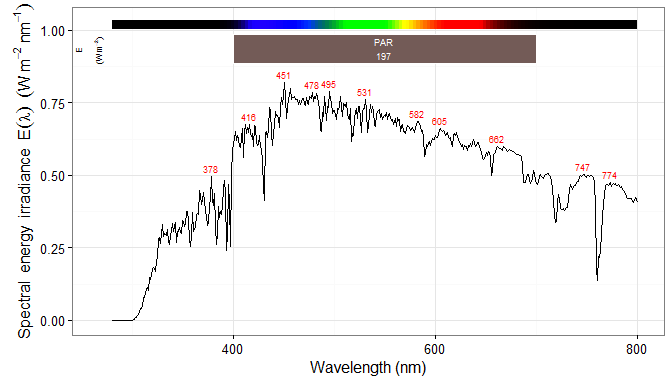

```r
plot(sun.spct, w.band = PAR())
```

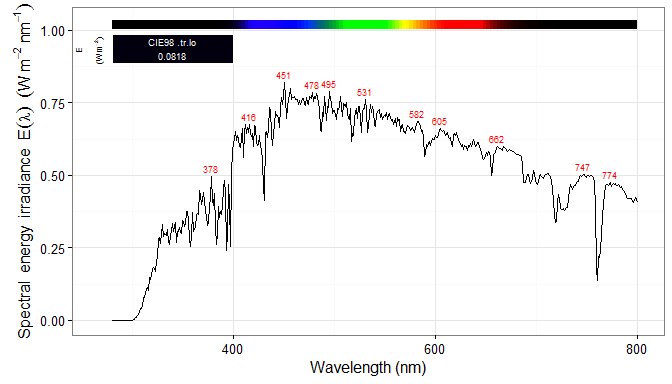

```r
plot(sun.spct, w.band = CIE())
```

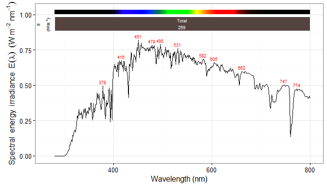

```r
plot(sun.spct, w.band = NULL)
```

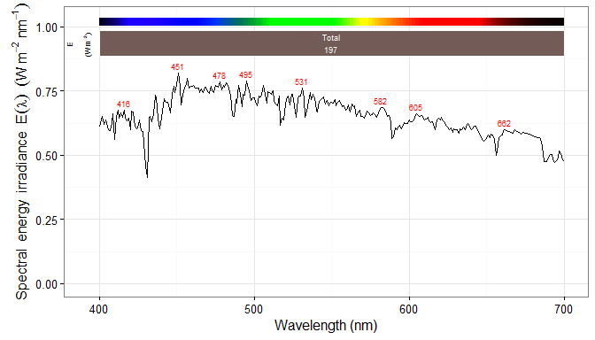

```r
plot(sun.spct, w.band = NULL, range = c(400,700))
```

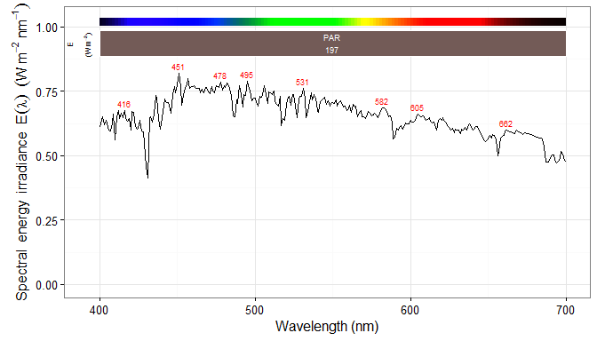

```r
plot(sun.spct, w.band = NULL, range = PAR())
```

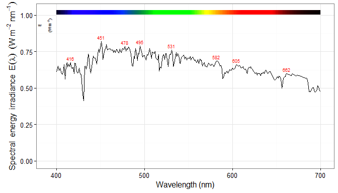

```r
plot(sun.spct, w.band = UVB(), range = c(400,700))
```

The time unit is also stored in the metadata, as demonstrated here. The units in axis labels have suitably adapted to the different units.

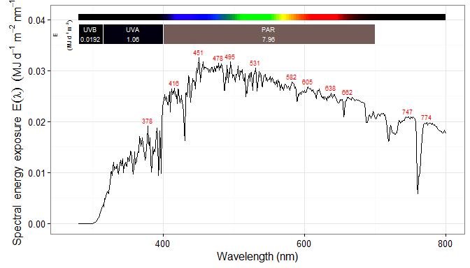

```r
plot(sun.daily.spct)
```

Even though the `plot()` methods can return a finished plot, the returned object is a `ggplot` object and can be built upon by adding additional elements like *facets*, *aesthetics* and even additional *layers*.

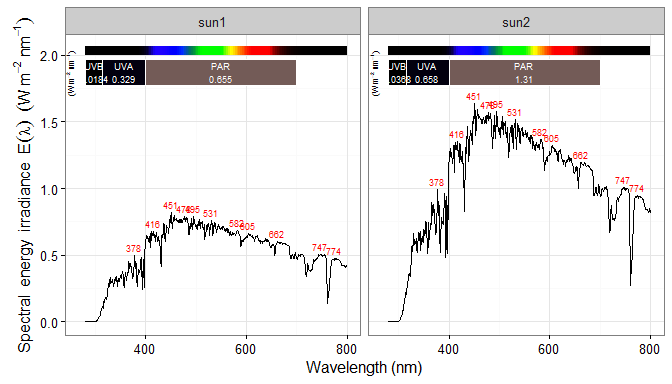

```r
plot(two_suns.spct, label.qty = "mean") + facet_wrap(~spct.idx)
```

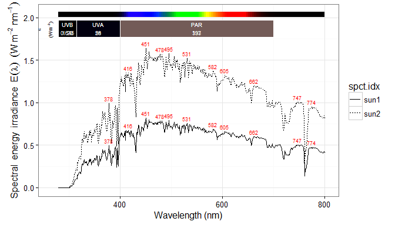

```r
plot(two_suns.spct) + aes(linetype = spct.idx)
```

Here we demonstrate something that may look like a bug, but is not. The annotations are based only on the data supplied as argument to `plot()` (or in other cases `ggplot()`) because these are the only data visible in all *layers*. The `data` argument in `geom_spct()` only affects the data seen by this *geom*. This way of building a plot is very different than when using *grouping* within a single data set, and it is best to avoid it in most situations.

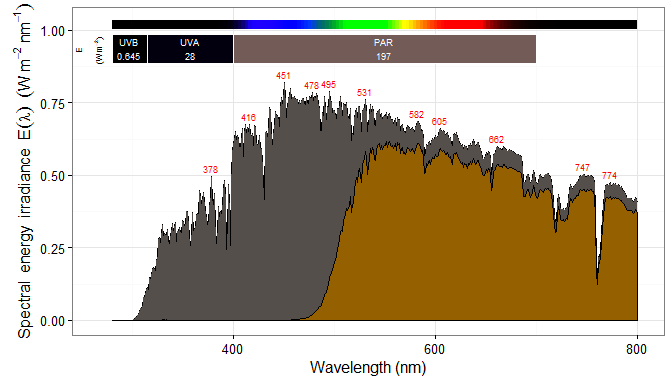

```r
plot(sun.spct) + geom_spct(fill = color(sun.spct)) +
  geom_spct(data = yellow_gel.spct * sun.spct, color = "black",
            fill = color(yellow_gel.spct * sun.spct))
```

In the examples above the `source_spct` object `sun.spct` was used. The `plot()` methods for other spectral classes have slight differentces. We show some examples for `filter_spct` obejcts.

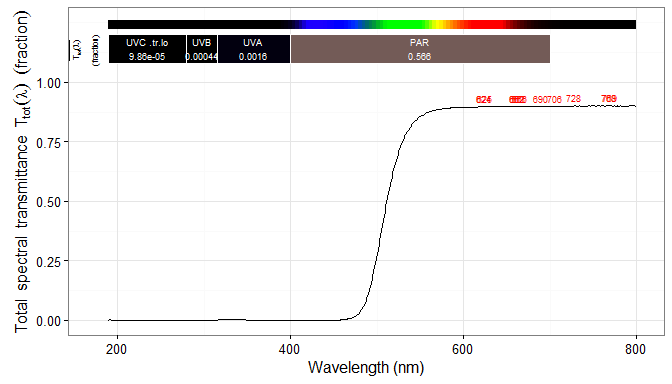

```r
plot(yellow_gel.spct)
```

By default transmittance, reflectance and absorptance are expressed as fractions of one, as in the plot above, but optionally per cents can be plotted.

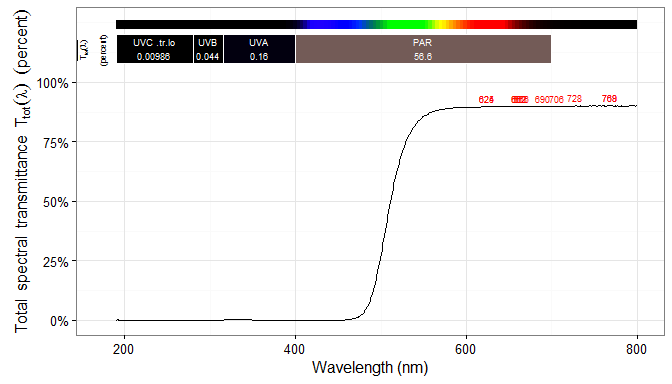

```r
plot(yellow_gel.spct, pc.out = TRUE)
```

In many cases it is possible to convert on-the-fly the quantity plotted.

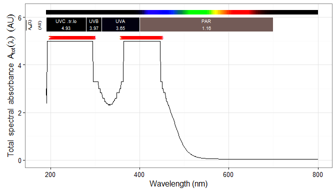

```r
plot(yellow_gel.spct, plot.qty = "absorbance")
```

We add a *guessed* spectral reflectance to the data object to allow the estimation of absorptance.

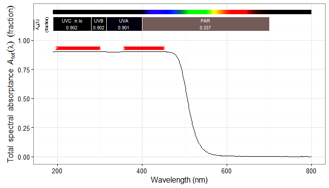

```r
yellow_gel.spct$Rfr <- 1 - max(yellow_gel.spct$Tfr)
plot(yellow_gel.spct, plot.qty = "absorptance")
```

If one really needs to, one can add a suitable *stat* using ‘local’ data. As this is just a demonstration, I will avoid adding all the additional arguments needed to make the annotations of peaks match those produced by `plot()`.

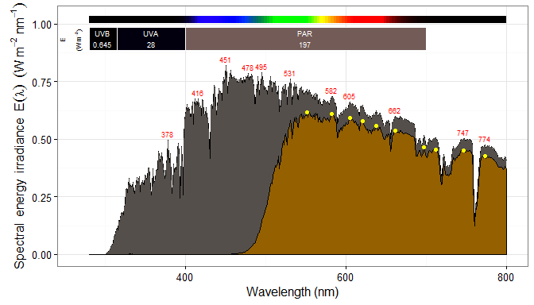

```r
plot(sun.spct) + geom_spct(fill = color(sun.spct)) +
  geom_spct(data = yellow_gel.spct * sun.spct, color = "black",
            fill = color(yellow_gel.spct * sun.spct)) +
  stat_peaks(data = yellow_gel.spct * sun.spct, color = "yellow",
             ignore_threshold = 0.1, span = 21)
```

As with any `ggplot` object, the ‘looks’ of the returned object depends on both the local and global `ggplot` *theme*.

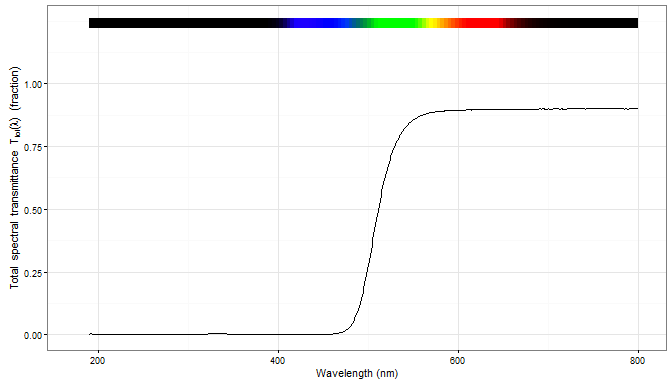

```r
theme_set(theme_bw(8))
plot(yellow_gel.spct, annotations = "colour.guide")
theme_set(theme_bw())
```